# Shiny Application and Reproducible Pitch

Rodrigo Padilla

3/15/2021

# About the Assignment (1/2)

Your Shiny Application

1. Write a shiny application with associated supporting documentation. The documentation should be thought of as whatever a user will need to get started using your application.
2. Deploy the application on Rstudio’s shiny server
3. Share the application link by pasting it into the provided text box
4. Share your server.R and ui.R code on github

# About the Assignment (2/2)

The application must include the following:

1. Some form of input (widget: textbox, radio button, checkbox, …)
2. Some operation on the ui input in sever.R
3. Some reactive output displayed as a result of server calculations
4. You must also include enough documentation so that a novice user could use your application.
5. The documentation should be at the Shiny website itself. Do not post to an external link.

# How to use the application

By using the already existing dataset “Galton Families”. A linear model was fit to a linear model to predict a child’s height based on the gener and the parent’s average height.

You can find the application on: https://hrpc87.shinyapps.io/ShinyApp/

# About the dataset “Galton Families”

The Galton dataset on the heights of parents and their children.

```
##      family        father         mother      midparentHeight    children
##  185    : 15   Min.   :62.0   Min.   :58.00   Min.   :64.40   Min.   : 1.000
##  066    : 11   1st Qu.:68.0   1st Qu.:63.00   1st Qu.:68.14   1st Qu.: 4.000
##  120    : 11   Median :69.0   Median :64.00   Median :69.25   Median : 6.000
##  130    : 11   Mean   :69.2   Mean   :64.09   Mean   :69.21   Mean   : 6.171
##  166    : 11   3rd Qu.:71.0   3rd Qu.:65.88   3rd Qu.:70.14   3rd Qu.: 8.000
##  097    : 10   Max.   :78.5   Max.   :70.50   Max.   :75.43   Max.   :15.000
##  (Other):865
##     childNum         gender     childHeight
##  Min.   : 1.000   female:453   Min.   :56.00
##  1st Qu.: 2.000   male  :481   1st Qu.:64.00
##  Median : 3.000                Median :66.50
##  Mean   : 3.586                Mean   :66.75
##  3rd Qu.: 5.000                3rd Qu.:69.70
##  Max.   :15.000                Max.   :79.00
##
```

# Scatterplot

In the scatterplot below are represented the data used for the prediction model

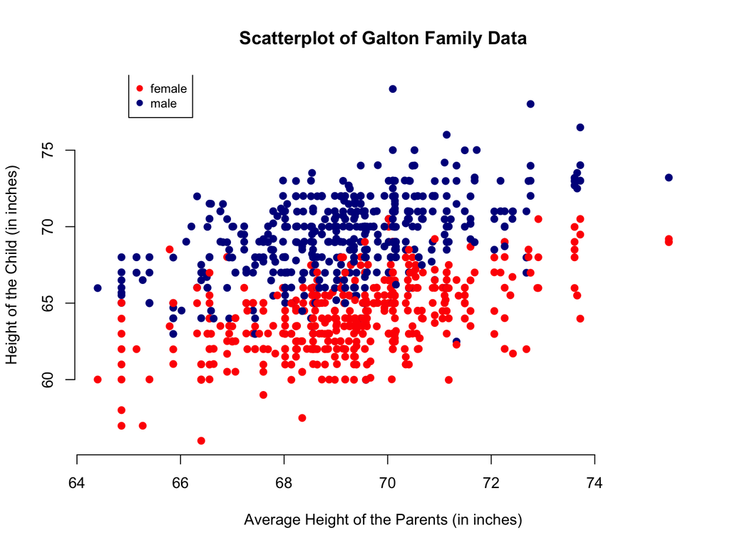